# Tutorial 3/4

Karen Hwang

09/10/2020

## Exercise 1.1: Regression

```r
#Added CRAN portion since it was having problems with knitting without it
r = getOption("repos")
r["CRAN"] = "http://cran.us.r-project.org"
options(repos = r)
install.packages("readxl")
suppressPackageStartupMessages(library(readxl))
data_reg3 <- read_excel("example_linear-reg_dataset1.xls", sheet = "Hoja3")
lmHeight3 = lm(height~age + playtime, data = data_reg3)

summary(lmHeight3)
```

```
##
## Call:
## lm(formula = height ~ age + playtime, data = data_reg3)
##
## Residuals:
##      Min       1Q   Median       3Q      Max
## -0.36793 -0.18717  0.03282  0.10406  0.53356
##
## Coefficients:
##             Estimate Std. Error t value Pr(>|t|)
## (Intercept) 56.48302    0.41013 137.720 2.85e-16 ***
## age          0.98463    0.02434  40.453 1.72e-11 ***
## playtime     0.01388    0.03276   0.424    0.682
## ---
## Signif. codes:  0 '***' 0.001 '**' 0.01 '*' 0.05 '.' 0.1 ' ' 1
##
## Residual standard error: 0.2909 on 9 degrees of freedom
## Multiple R-squared:  0.9945, Adjusted R-squared:  0.9933
## F-statistic: 819.8 on 2 and 9 DF,  p-value: 6.564e-11
```

### Regression Plot

The residuals appear to be random

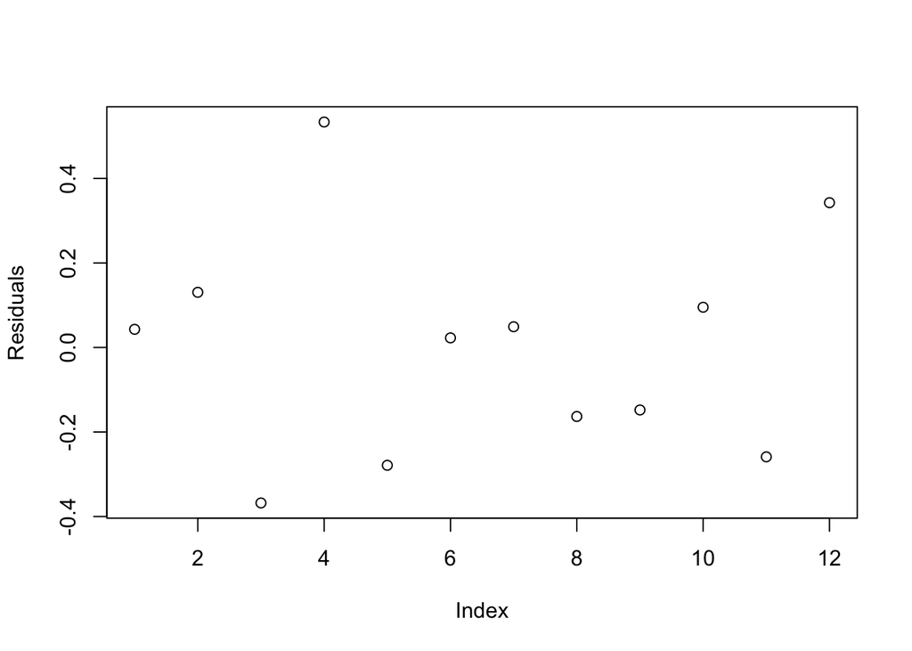

```r
plot(lmHeight3$residuals, ylab='Residuals')
```

## Exercise 2.1: Clustering

```r
set.seed(786)
data_seeds <- read.csv("seeds_dataset.txt" ,sep = '\t',header = FALSE)
feature_name <- c('area','perimeter','compactness','length.of.kernel','width.of.kernal','asymmetry.coefficient','length.of.kernel.groove','type.of.seed')
colnames(data_seeds) <- feature_name

#check if everything is numerical and for any missing/NA values
str(data_seeds)
```

```
## 'data.frame':    210 obs. of  8 variables:
##  $ area                   : num  15.3 14.9 14.3 13.8 16.1 ...
##  $ perimeter              : num  14.8 14.6 14.1 13.9 15 ...
##  $ compactness            : num  0.871 0.881 0.905 0.895 0.903 ...
##  $ length.of.kernel       : num  5.76 5.55 5.29 5.32 5.66 ...
##  $ width.of.kernal        : num  3.31 3.33 3.34 3.38 3.56 ...
##  $ asymmetry.coefficient  : num  2.22 1.02 2.7 2.26 1.35 ...
##  $ length.of.kernel.groove: num  5.22 4.96 4.83 4.8 5.17 ...
##  $ type.of.seed           : int  1 1 1 1 1 1 1 1 1 1 ...
```

```r
any(is.na(data_seeds))
```

```
## [1] FALSE
```

```r
#Exclude the type.of.seed column from the dataset in order to do clustering
seeds_label <- data_seeds$type.of.seed
data_seeds$type.of.seed <- NULL

#Scale all the columns
data_seeds_norm <- as.data.frame(scale(data_seeds))
summary(data_seeds_norm)
```

```
##       area           perimeter        compactness      length.of.kernel
##  Min.   :-1.4632   Min.   :-1.6458   Min.   :-2.6619   Min.   :-1.6466
##  1st Qu.:-0.8858   1st Qu.:-0.8494   1st Qu.:-0.5967   1st Qu.:-0.8267
##  Median :-0.1693   Median :-0.1832   Median : 0.1037   Median :-0.2371
##  Mean   : 0.0000   Mean   : 0.0000   Mean   : 0.0000   Mean   : 0.0000
##  3rd Qu.: 0.8446   3rd Qu.: 0.8850   3rd Qu.: 0.7100   3rd Qu.: 0.7927
##  Max.   : 2.1763   Max.   : 2.0603   Max.   : 2.0018   Max.   : 2.3619
##  width.of.kernal   asymmetry.coefficient length.of.kernel.groove
##  Min.   :-1.6642   Min.   :-1.95210      Min.   :-1.8090
##  1st Qu.:-0.8329   1st Qu.:-0.75734      1st Qu.:-0.7387
##  Median :-0.0572   Median :-0.06731      Median :-0.3766
##  Mean   : 0.0000   Mean   : 0.00000      Mean   : 0.0000
##  3rd Qu.: 0.8026   3rd Qu.: 0.71068      3rd Qu.: 0.9541
##  Max.   : 2.0502   Max.   : 3.16303      Max.   : 2.3234
```

```r
#Build distance matrix
dist_mat <- dist(data_seeds_norm, method = 'euclidean')
```

### Hierarchical Clustering - Complete Linkage

```r
hclust_comp <- hclust(dist_mat, method = 'complete')
plot(hclust_comp)

cut_comp <- cutree(hclust_comp, k = 3)
plot(hclust_comp)
rect.hclust(hclust_comp , k = 3, border = 2:6)

abline(h = 3, col = 'red')

suppressPackageStartupMessages(library(dplyr))
data_seeds_comp_cl <- mutate(data_seeds, cluster = cut_comp)
count(data_seeds_comp_cl,cluster)
```

```
##   cluster  n
## 1       1 52
## 2       2 68
## 3       3 90
```

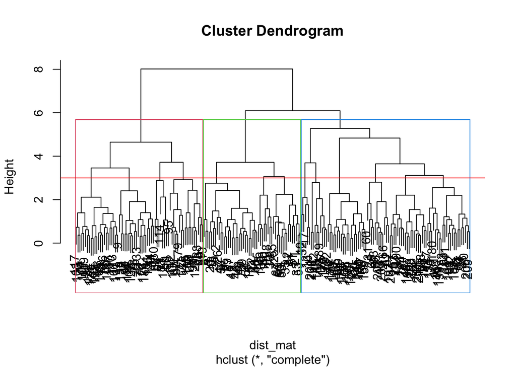

```r
suppressPackageStartupMessages(library(ggplot2))
```

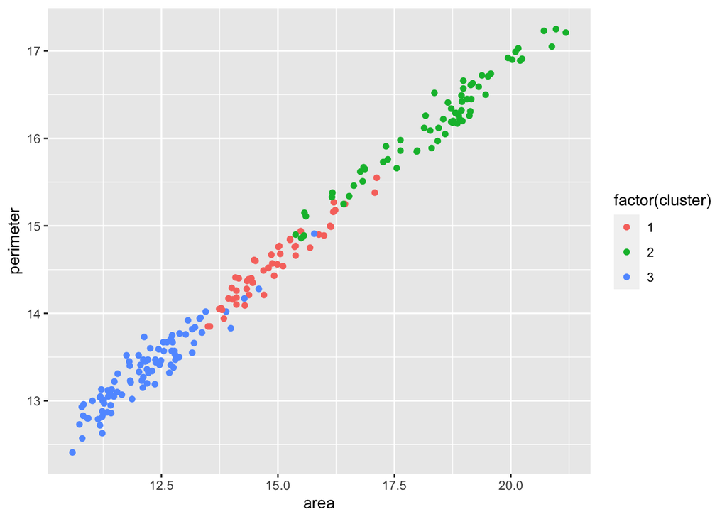

```r
ggplot(data_seeds_comp_cl, aes(x=area, y = perimeter, color = factor(cluster))) + geom_point()
```

```r
table(data_seeds_comp_cl$cluster,seeds_label)
```

```
##    seeds_label
##      1  2  3
##   1 48  4  0
##   2  2 66  0
##   3 20  0 70
```

### Hierarchal Clustering - Average Linkage

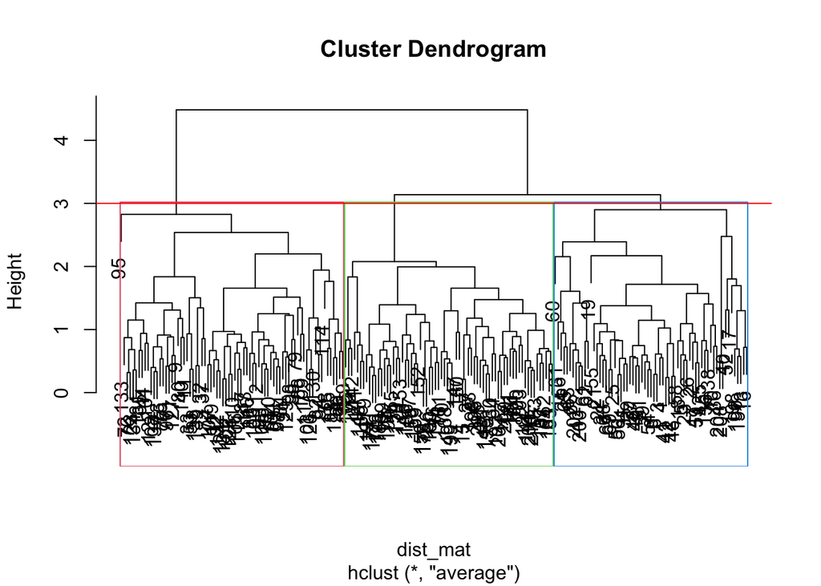

```r
hclust_avg <- hclust(dist_mat, method = 'average')
plot(hclust_avg)

cut_avg <- cutree(hclust_avg, k = 3)
plot(hclust_avg)
rect.hclust(hclust_avg , k = 3, border = 2:6)

abline(h = 3, col = 'red')
```

```r
suppressPackageStartupMessages(library(dplyr))
data_seeds_avg_cl <- mutate(data_seeds, cluster = cut_avg)
count(data_seeds_avg_cl,cluster)
```

```
##   cluster  n
## 1       1 65
## 2       2 75
## 3       3 70
```

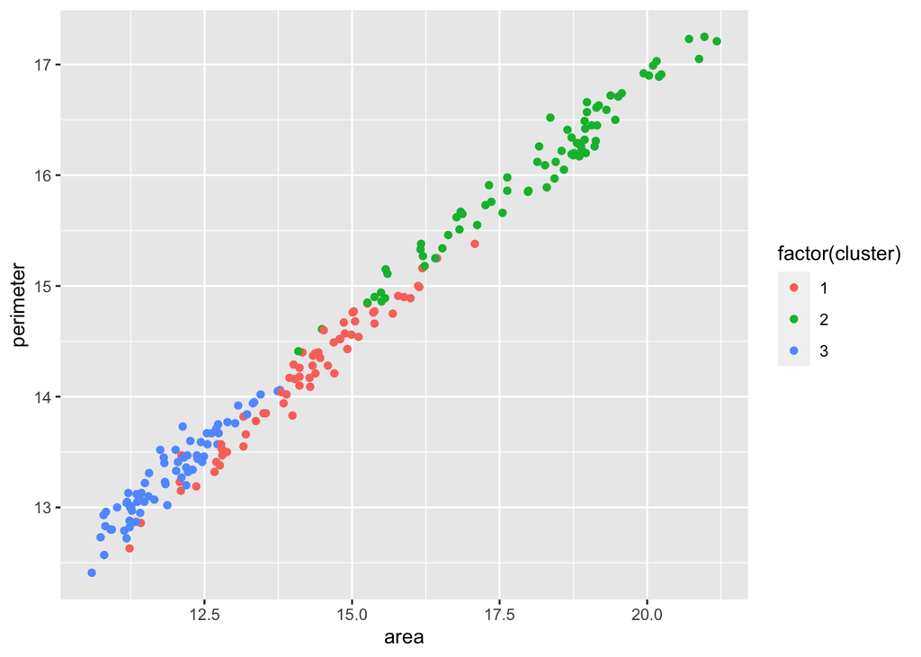

```r
suppressPackageStartupMessages(library(ggplot2))
ggplot(data_seeds_avg_cl, aes(x=area, y = perimeter, color = factor(cluster))) + geom_point()
```

```r
table(data_seeds_avg_cl$cluster,seeds_label)
```

```
##    seeds_label
##      1  2  3
##   1 55  2  8
##   2  7 68  0
##   3  8  0 62
```

### Comparison Between Complete and Average Linkage

Clustering led to a positive linear relationship between perimeter and area for all varieties of wheat using both complete and average linkage. Complete linkage grouped 52, 68, and 90 observations into clusters 1, 2, and 3 respectively, while average linkage yielded 65, 75, and 70. Since there were originally 70 observations for each wheat variety, average linkage appears to have produced more accurate clusters. From the table of the seed labels with corresponding clusters, Complete linkage accurately captured all 70 observations for seed type 3, 66 for seed type 2, but only captured 48 for seed type 1, grouping around 30% of type 1 into clusters 2 and 3. On the other hand, average linkage accurately captured 55, 68, and 62 for seed types 1, 2, and 3 respectively. While both methods resulted in clusters that adequately represent the different seeds, average clustering seemed to result in better results overall.

## Exercise 2.2 - PCA of mtcars Dataset

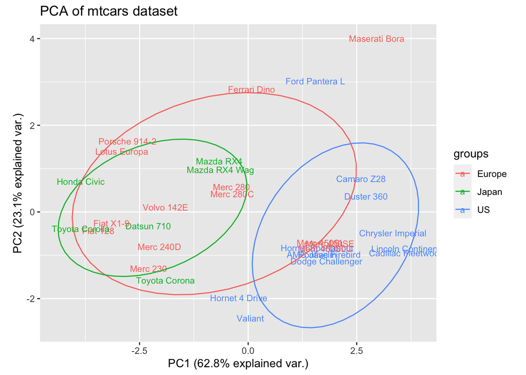

```r
mtcars.pca <- prcomp(mtcars[,c(1:7,10,11)], center = TRUE,scale. = TRUE)

suppressPackageStartupMessages(library(ggbiplot))

#Categorize these cars into US, Japanese and European:
mtcars.country <- c(rep("Japan", 3), rep("US",4), rep("Europe", 7),rep("US",3), "Europe", rep("Japan", 3), rep("US",4), rep("Europe", 3), "US", rep("Europe", 3))
ggbiplot(mtcars.pca,ellipse=TRUE,obs.scale = 1, var.scale = 1,var.axes=FALSE,   labels=rownames(mtcars), groups=mtcars.country) + ggtitle("PCA of mtcars dataset")
```

## Exercise 3.1 - Classification

```r
suppressPackageStartupMessages(require(ISLR))
head(Smarket)
```

```
##   Year   Lag1   Lag2   Lag3   Lag4   Lag5 Volume  Today Direction
## 1 2001  0.381 -0.192 -2.624 -1.055  5.010 1.1913  0.959        Up
## 2 2001  0.959  0.381 -0.192 -2.624 -1.055 1.2965  1.032        Up
## 3 2001  1.032  0.959  0.381 -0.192 -2.624 1.4112 -0.623      Down
## 4 2001 -0.623  1.032  0.959  0.381 -0.192 1.2760  0.614        Up
## 5 2001  0.614 -0.623  1.032  0.959  0.381 1.2057  0.213        Up
## 6 2001  0.213  0.614 -0.623  1.032  0.959 1.3491  1.392        Up
```

### Boxplot

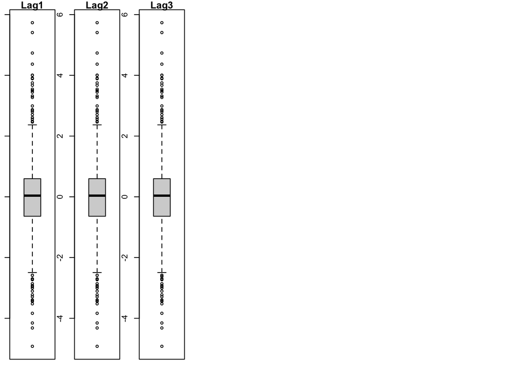

```r
par(mfrow=c(1,8))
par(mar=c(1,1,1,1))
for(i in 2:4) {
  boxplot(Smarket[,i], main=names(Smarket)[i])
}
```

### Correlation plot

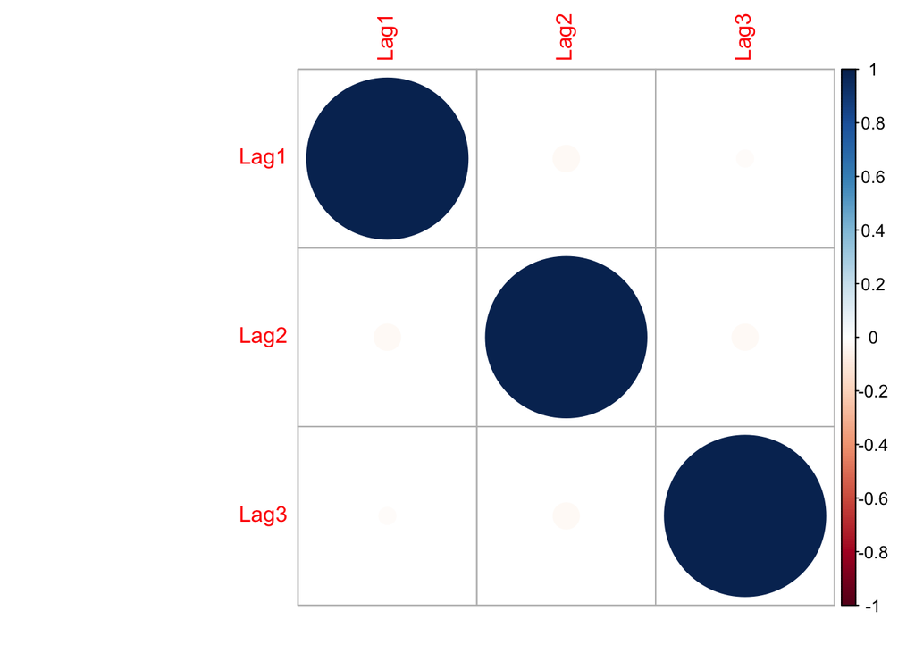

```r
suppressPackageStartupMessages(library(corrplot))
correlations <- cor(Smarket[,2:4])
corrplot(correlations, method="circle")
```

### Density distribution plot

```r
library(caret)
```

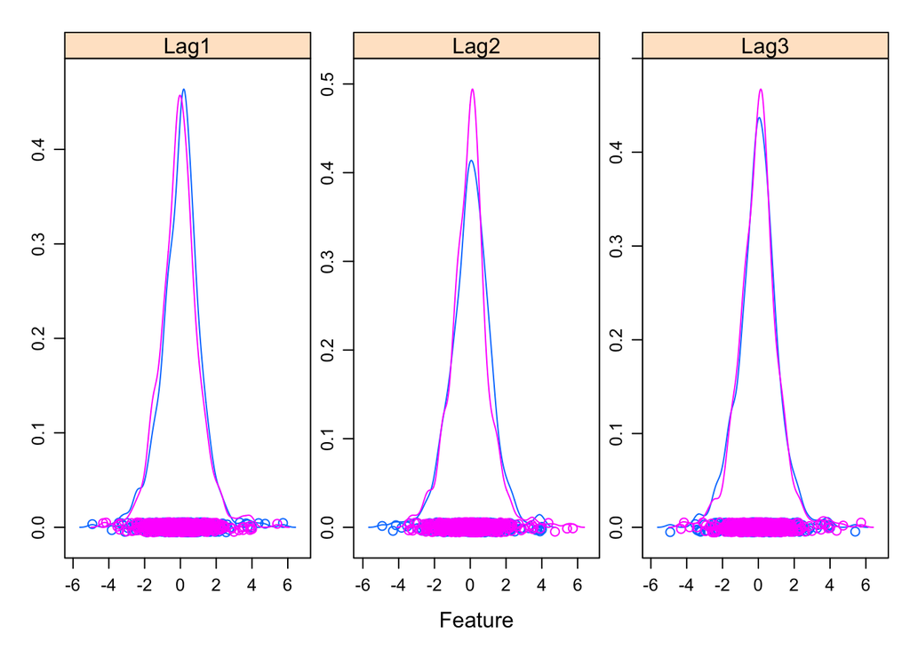

```r
x <- Smarket[,2:4]
y <- Smarket[,9]
scales <- list(x=list(relation="free"), y=list(relation="free"))
featurePlot(x=x, y=y, plot="density", scales=scales)
```

### Logistic Regression Model & Summary

```r
glm.fit <- glm(Direction ~ Lag1 + Lag2 + Lag3, data = Smarket, family = binomial)
summary(glm.fit)
```

```
##
## Call:
## glm(formula = Direction ~ Lag1 + Lag2 + Lag3, family = binomial,
##     data = Smarket)
##
## Deviance Residuals:
##    Min      1Q  Median      3Q     Max
## -1.384  -1.204   1.077   1.146   1.348
##
## Coefficients:
##              Estimate Std. Error z value Pr(>|z|)
## (Intercept)  0.074230   0.056672   1.310    0.190
## Lag1        -0.071404   0.050102  -1.425    0.154
## Lag2        -0.044260   0.050019  -0.885    0.376
## Lag3         0.008873   0.049855   0.178    0.859
##
## (Dispersion parameter for binomial family taken to be 1)
##
##     Null deviance: 1731.2  on 1249  degrees of freedom
## Residual deviance: 1728.4  on 1246  degrees of freedom
## AIC: 1736.4
##
## Number of Fisher Scoring iterations: 3
```

### Predictions and Fitter Probabilities

```r
glm.probs <- predict(glm.fit,type = "response")
glm.probs[1:5]
```

```
##         1         2         3         4         5
## 0.5080596 0.4967968 0.4903703 0.5203756 0.5167732
```

### Classify Up or Down

```r
glm.pred <- ifelse(glm.probs > 0.5, "Up", "Down")
attach(Smarket)
table(glm.pred,Direction)
```

```
##         Direction
## glm.pred Down  Up
##     Down  114  97
##     Up    488 551
```

### Classification Rate

```r
mean(glm.pred == Direction)
```

```
## [1] 0.532
```